# **Bikeshare_casestudy**

Giang Nguyen

15.10.2025

## Step 1: Ask - Define the business tasks

### 1.1. Business Task

Identify differences in bike usage between casual riders and annual members to create a marketing plan that converts casual riders into annual members.

### 1.2. Questions for analysis

- How do annual members and casual riders use Cyclistic bikes differently? What are casual rides usage patterns (e.g., trip length, days of the week, time of day) compared to members?
- Why would casual riders buy Cyclistic annual memberships?
- How can Cyclistic use digital media to influence casual riders to become members?

## Step 2: Prepare - Collect and load data

### 2.1. Install and load essential packages

```r
library(tidyverse) # For data manipulation and cleaning
```

```r
library(lubridate) # For handling date/time data
library(ggplot2) # For visualizing data
```

### 2.2. Load data

For this case study, I use these public datasets [Divvy 2019 Q1](https://docs.google.com/spreadsheets/d/1uCTsHlZLm4L7-ueaSLwDg0ut3BP_V4mKDo2IMpaXrk4/template/preview?resourcekey=0-dQAUjAu2UUCsLEQQt20PDA#gid=1797029090) and [Divvy 2020 Q1](https://docs.google.com/spreadsheets/d/179QVLO_yu5BJEKFVZShsKag74ZaUYIF6FevLYzs3hRc/template/preview#gid=640449855).

```r
q1_2019 <- read_csv("Divvy_Trips_2019_Q1.csv")
q1_2020 <- read_csv("Divvy_Trips_2020_Q1.csv")
```

### 2.3. Initial Inspection

```r
colnames(q1_2019)
```

```
##  [1] "trip_id"           "start_time"        "end_time"
##  [4] "bikeid"            "tripduration"      "from_station_id"
##  [7] "from_station_name" "to_station_id"     "to_station_name"
## [10] "usertype"          "gender"            "birthyear"
```

```r
colnames(q1_2020)
```

```
##  [1] "ride_id"            "rideable_type"      "started_at"
##  [4] "ended_at"           "start_station_name" "start_station_id"
##  [7] "end_station_name"   "end_station_id"     "start_lat"
## [10] "start_lng"          "end_lat"            "end_lng"
## [13] "member_casual"
```

```r
str(q1_2019)
```

```
## spc_tbl_ [365,069 × 12] (S3: spec_tbl_df/tbl_df/tbl/data.frame)
##  $ trip_id          : num [1:365069] 21742443 21742444 21742445 21742446 21742447 ...
##  $ start_time       : chr [1:365069] "2019-01-01 0:04:37" "2019-01-01 0:08:13" "2019-01-01 0:13:23" "2019-01-01 0:13:45" ...
##  $ end_time         : chr [1:365069] "2019-01-01 0:11:07" "2019-01-01 0:15:34" "2019-01-01 0:27:12" "2019-01-01 0:43:28" ...
##  $ bikeid           : num [1:365069] 2167 4386 1524 252 1170 ...
##  $ tripduration     : num [1:365069] 390 441 829 1783 364 ...
##  $ from_station_id  : num [1:365069] 199 44 15 123 173 98 98 211 150 268 ...
##  $ from_station_name: chr [1:365069] "Wabash Ave & Grand Ave" "State St & Randolph St" "Racine Ave & 18th St" "California Ave & Milwaukee Ave" ...
##  $ to_station_id    : num [1:365069] 84 624 644 176 35 49 49 142 148 141 ...
##  $ to_station_name  : chr [1:365069] "Milwaukee Ave & Grand Ave" "Dearborn St & Van Buren St (*)" "Western Ave & Fillmore St (*)" "Clark St & Elm St" ...
##  $ usertype         : chr [1:365069] "Subscriber" "Subscriber" "Subscriber" "Subscriber" ...
##  $ gender           : chr [1:365069] "Male" "Female" "Female" "Male" ...
##  $ birthyear        : num [1:365069] 1989 1990 1994 1993 1994 ...
##  - attr(*, "spec")=
##   .. cols(
##   ..   trip_id = col_double(),
##   ..   start_time = col_character(),
##   ..   end_time = col_character(),
##   ..   bikeid = col_double(),
##   ..   tripduration = col_number(),
##   ..   from_station_id = col_double(),
##   ..   from_station_name = col_character(),
##   ..   to_station_id = col_double(),
##   ..   to_station_name = col_character(),
##   ..   usertype = col_character(),
##   ..   gender = col_character(),
##   ..   birthyear = col_double()
##   .. )
##  - attr(*, "problems")=<externalptr>
```

```r
str(q1_2020)
```

```
## spc_tbl_ [426,887 × 13] (S3: spec_tbl_df/tbl_df/tbl/data.frame)
##  $ ride_id           : chr [1:426887] "EACB19130B0CDA4A" "8FED874C809DC021" "789F3C21E472CA96" "C9A388DAC6ABF313" ...
##  $ rideable_type     : chr [1:426887] "docked_bike" "docked_bike" "docked_bike" "docked_bike" ...
##  $ started_at        : chr [1:426887] "2020-01-21 20:06:59" "2020-01-30 14:22:39" "2020-01-09 19:29:26" "2020-01-06 16:17:07" ...
##  $ ended_at          : chr [1:426887] "2020-01-21 20:14:30" "2020-01-30 14:26:22" "2020-01-09 19:32:17" "2020-01-06 16:25:56" ...
##  $ start_station_name: chr [1:426887] "Western Ave & Leland Ave" "Clark St & Montrose Ave" "Broadway & Belmont Ave" "Clark St & Randolph St" ...
##  $ start_station_id  : num [1:426887] 239 234 296 51 66 212 96 96 212 38 ...
##  $ end_station_name  : chr [1:426887] "Clark St & Leland Ave" "Southport Ave & Irving Park Rd" "Wilton Ave & Belmont Ave" "Fairbanks Ct & Grand Ave" ...
##  $ end_station_id    : num [1:426887] 326 318 117 24 212 96 212 212 96 100 ...
##  $ start_lat         : num [1:426887] 42 42 41.9 41.9 41.9 ...
##  $ start_lng         : num [1:426887] -87.7 -87.7 -87.6 -87.6 -87.6 ...
##  $ end_lat           : num [1:426887] 42 42 41.9 41.9 41.9 ...
##  $ end_lng           : num [1:426887] -87.7 -87.7 -87.7 -87.6 -87.6 ...
##  $ member_casual     : chr [1:426887] "member" "member" "member" "member" ...
##  - attr(*, "spec")=
##   .. cols(
##   ..   ride_id = col_character(),
##   ..   rideable_type = col_character(),
##   ..   started_at = col_character(),
##   ..   ended_at = col_character(),
##   ..   start_station_name = col_character(),
##   ..   start_station_id = col_double(),
##   ..   end_station_name = col_character(),
##   ..   end_station_id = col_double(),
##   ..   start_lat = col_double(),
##   ..   start_lng = col_double(),
##   ..   end_lat = col_double(),
##   ..   end_lng = col_double(),
##   ..   member_casual = col_character()
##   .. )
##  - attr(*, "problems")=<externalptr>
```

## Step 3: Process - Wrangle data and clean

### 3.1. Rename q1_2019 columns to match q1_2020 columns

```r
q1_2019 <- q1_2019 %>%
rename(ride_id = trip_id,
        rideable_type = bikeid, # This column hold bike type, but is 'bikeid' in q1_2019
        started_at = start_time,
        ended_at = end_time,
        start_station_name = from_station_name,
        end_station_name = to_station_name,
        start_station_id = from_station_id,
        end_station_id = to_station_id,
        member_casual = usertype)
```

### 3.2. Select, format, and combine data

#### 3.2.1. Select consistent columns and convert data type for merging

```r
q1_2019 <- q1_2019 %>%
  mutate(ride_id = as.character(ride_id),
         rideable_type = as.character(rideable_type),
         start_station_id = as.character(start_station_id),
         end_station_id = as.character(end_station_id))

q1_2020 <- q1_2020 %>%
  mutate(ride_id = as.character(ride_id),
         rideable_type = as.character(rideable_type),
         start_station_id = as.character(start_station_id),
         end_station_id = as.character(end_station_id))
```

```r
all_trips <- bind_rows(q1_2019, q1_2020)
```

#### 3.2.2. Remove the redundant/inconsistent columns

```r
all_trips <- all_trips %>%
  select(-c(gender, birthyear, tripduration, start_lat, start_lng, end_lat, end_lng))
```

#### 3.2.3. Convert q1_2019 user types (‘Subcriber’, ‘Customer’) to the q1_2020 format (‘member’, ‘casual’)

```r
all_trips <- all_trips %>%
  mutate(member_casual = recode(member_casual,
                                "Subscriber" = "member",
                                "Customer" = "casual"))
```

#### 3.2.4. Create a new column ‘ride_length’ in seconds

#Ensure ‘started_at’ and ‘ended_at’ are in datetime format first

```r
all_trips <- all_trips %>%
  mutate(started_at = ymd_hms(started_at),
         ended_at = ymd_hms(ended_at),
         ride_length = difftime(ended_at, started_at, units = "secs"))
```

#### 3.2.5. Create date/time components for analysis

```r
all_trips <- all_trips %>%
  mutate(date = as.Date(started_at),
         month = month(started_at, label = TRUE),
         day_of_week = wday(started_at, label = TRUE, abbr = FALSE),
         year = year(started_at),
         hour = hour(started_at))
```

#### 3.2.6. Filter out negative/zero-length rides and rides longer than 24 hours (extreme outliers)

```r
all_trips_v2 <- all_trips %>%
  filter(ride_length > 60 & ride_length < 86400) #Filter for rides between 60s and 24 hours
```

#### 3.2.7. Drop any rows with missing station names that may interfere with station analysis

```r
all_trips_v2 <- na.omit(all_trips_v2)
```

## Step 4: Analyze - Aggregate and Summarize

Use the cleaned data (all_trip_v2) to find key differences between **member** and **casual** riders.

### 4.1. Overall Summary Statistics (Ride count and average ride length)

```r
all_trips_v2 %>%
  group_by(member_casual) %>%
  summarise(
    total_rides = n(),
    average_length_min = mean(ride_length)/60
  )
```

```
## # A tibble: 2 × 3
##   member_casual total_rides average_length_min
##   <chr>               <int> <drtn>
## 1 casual              67397 38.48317 secs
## 2 member             716381 11.46731 secs
```

### 4.2. Analyze usage by days of week

```r
all_trips_v2 %>%
  group_by(member_casual, day_of_week) %>%
  summarise(
    number_of_rides = n(),
    average_duration = mean(ride_length)
  ) %>%
  arrange(member_casual, day_of_week)
```

```
## # A tibble: 14 × 4
## # Groups:   member_casual [2]
##    member_casual day_of_week number_of_rides average_duration
##    <chr>         <ord>                 <int> <drtn>
##  1 casual        Sunday                18512 2460.0646 secs
##  2 casual        Monday                 5558 2069.8239 secs
##  3 casual        Tuesday                7266 2140.1636 secs
##  4 casual        Wednesday              7623 2477.2515 secs
##  5 casual        Thursday               7085 2122.1764 secs
##  6 casual        Friday                 7954 2232.1902 secs
##  7 casual        Saturday              13399 2339.6712 secs
##  8 member        Sunday                59694  781.3531 secs
##  9 member        Monday               109852  669.5708 secs
## 10 member        Tuesday              127359  682.4684 secs
## 11 member        Wednesday            121296  673.3301 secs
## 12 member        Thursday             124562  667.4294 secs
## 13 member        Friday               114586  669.1505 secs
## 14 member        Saturday              59032  750.4314 secs
```

### 4.3. Analyze usage by month

```r
all_trips_v2 %>%
  group_by(member_casual, month) %>%
  summarize(
    number_of_rides = n(),
    average_duration = mean(ride_length)
  ) %>%
  arrange(member_casual, month)
```

```
## # A tibble: 6 × 4
## # Groups:   member_casual [2]
##   member_casual month number_of_rides average_duration
##   <chr>         <ord>           <int> <drtn>
## 1 casual        Jan             12269 2177.4414 secs
## 2 casual        Feb             14833 2257.0022 secs
## 3 casual        Mar             40295 2368.1818 secs
## 4 member        Jan            233466  666.9463 secs
## 5 member        Feb            218905  668.9602 secs
## 6 member        Mar            264010  722.5090 secs
```

### 4.4. Identify top 10 starting stations for each user type

```r
all_trips_v2 %>%
  group_by(member_casual, start_station_name) %>%
  summarise(ride_count = n()) %>%
  arrange(member_casual, desc(ride_count)) %>%
  slice(1:10)
```

```
## # A tibble: 20 × 3
## # Groups:   member_casual [2]
##    member_casual start_station_name           ride_count
##    <chr>         <chr>                             <int>
##  1 casual        Streeter Dr & Grand Ave            2733
##  2 casual        Lake Shore Dr & Monroe St          2726
##  3 casual        Shedd Aquarium                     1828
##  4 casual        Millennium Park                    1401
##  5 casual        Michigan Ave & Oak St              1015
##  6 casual        Michigan Ave & Washington St        834
##  7 casual        Dusable Harbor                      829
##  8 casual        Adler Planetarium                   824
##  9 casual        Theater on the Lake                 792
## 10 casual        Lake Shore Dr & North Blvd          603
## 11 member        Canal St & Adams St               13750
## 12 member        Clinton St & Washington Blvd      13389
## 13 member        Clinton St & Madison St           12836
## 14 member        Kingsbury St & Kinzie St           8684
## 15 member        Columbus Dr & Randolph St          8467
## 16 member        Canal St & Madison St              7858
## 17 member        Franklin St & Monroe St            6971
## 18 member        Michigan Ave & Washington St       6671
## 19 member        Larrabee St & Kingsbury St         6442
## 20 member        Clinton St & Lake St               6418
```

## Step 5: Share - Visualizing data

### 5.1. Compare total rides by days of week

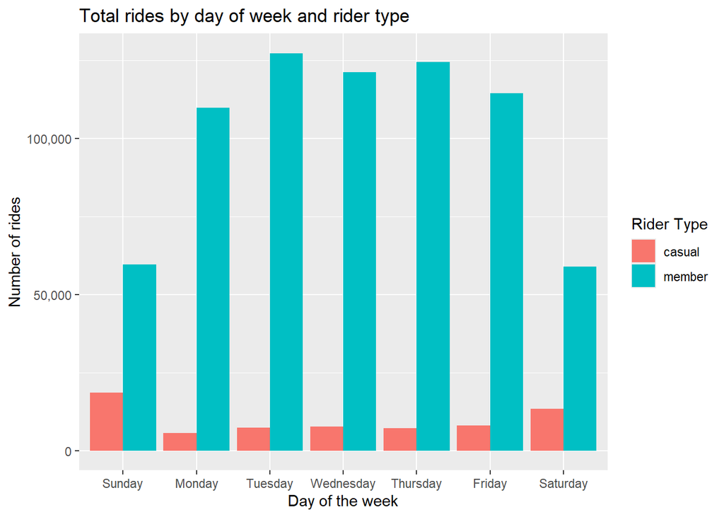

```r
all_trips_v2 %>%
  group_by(member_casual, day_of_week) %>%
  summarize(number_of_rides = n(), .groups = 'drop') %>%
  ggplot(aes(x=day_of_week, y=number_of_rides, fill=member_casual)) +
  geom_col(position = "dodge") +
  labs( title = "Total rides by day of week and rider type",
        x = "Day of the week",
        y = "Number of rides",
        fill = "Rider Type") +
  scale_y_continuous(labels = scales::comma)
```

### 5.2. Average ride lenghth by day of week

```
## Defaulting to continuous.
```

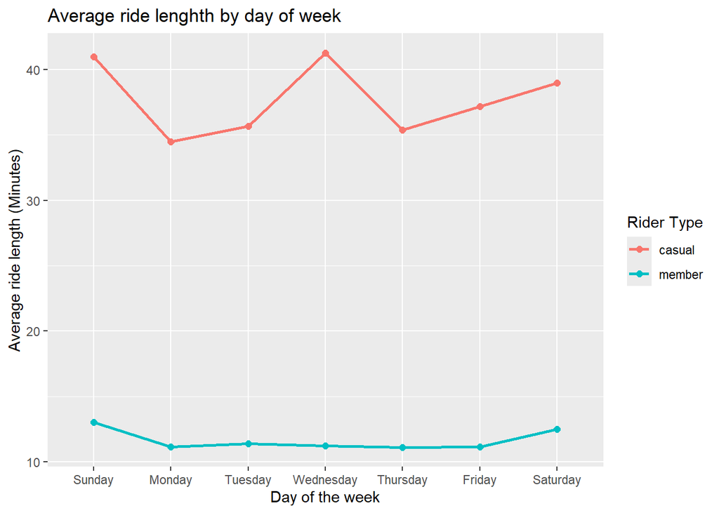

```r
all_trips_v2 %>%
  group_by(member_casual, day_of_week) %>%
  summarise(average_duration = mean(ride_length)/60, .groups = 'drop') %>%
  ggplot(aes(x= day_of_week, y=average_duration, color = member_casual, group =member_casual)) +
  geom_line(linewidth = 1) +
  geom_point(size = 2) +
  labs(title = "Average ride lenghth by day of week",
       x="Day of the week",
       y="Average ride length (Minutes)",
       color = "Rider Type")
```

## Step 6: Act - Formulate recommendations

- Casual riders take significantly longer rides, especially on Wednesday and weekends. Hence, the **recommendation** is target casual riders with a “Warrior” promotion on Wednesday and weekends, highlighting the cost savings on long-duration rides compared to daily passes.
- Casual rider activity peaks on Saturdays and Sundays. Therefore, the **recommendation** is launch a marketing campaign on Fridays that uses a time-sensitive incentive (“Unlock your first month free with an annual pass this weekend!”) to capture their weekend leisure demand.
- Members primarily use the service during weekday for short trips. So, the **recommendation** is focus digital ads (geotargeted around popular weekend leisure spots) that emphasize the convenience and unlimited nature of annual passes for recurring fun trips.
- Target Locations: Focus all physical and digital marketing efforts (geo-fencing, digital screens) at and around the top three casual starting stations: Streeter Dr & Grand Ave, Lake Shore Dr & Monroe St, Shedd Aquarium.